# Brecha de acceso en escuelas

Equipo Rojo Fuego

07/2020

$~$

En el siguiente informe se estudiarán las brechas de acceso en escuelas utilizando una base de datos del DIEE.

$~$

# **Preparación**

$~$

Corremos las librerías:

```r
library(readr)
library(tidyverse)
library(dplyr)
library(ggplot2)
library(plotly)
```

El siguiente dataset será utilizado para ver en qué situación se encuentran las escuelas de CABA con respecto a la brecha de acceso:

```r
Caracteristicas <- read_delim("https://media.githubusercontent.com/media/Agustin-Bulzomi/Projects/main/Programming/Support_Files/Caracteristicas.csv", ";", escape_double = FALSE, trim_ws = TRUE)
```

$~$

# **Análisis de brecha de acceso**

$~$

Primero, filtramos la base por las escuelas estatales ubicadas en CABA y seleccionamos la columna que consulta sobre la conexión a internet en las aulas:

```r
Escuelas <- filter(Caracteristicas, provincia == "Ciudad de Buenos Aires",
                   sector == "Estatal") %>%
  select("Espacios con conexión - En las aulas")
```

Para poder analizar la tabla, cambiamos las respuestas “X” por “Sí” y los campos vacios (NA) por “No”

```r
Escuelas$"Espacios con conexión - En las aulas"[Escuelas$"Espacios con conexión - En las aulas" == "X"] <- "Sí"
Escuelas$"Espacios con conexión - En las aulas"[is.na(Escuelas$"Espacios con conexión - En las aulas")] <- "No"
View(Escuelas)
```

Renombramos la columna y calculamos el total de escuelas que tienen internet en las aulas:

```r
Escuelas <- rename(Escuelas, Respuestas="Espacios con conexión - En las aulas")
Total <- group_by(Escuelas, Respuestas)%>%
  summarise(Total_Internet_Aula = n())

View(Total)
```

Ahora, vamos a proceder de la misma manera para averiguar si las escuelas tienen sala o laboratorio de informática. Primero, filtramos por escuelas estatales de CABA y seleccionamos la columna con la información requerida:

```r
Laboratorio <- filter(Caracteristicas, provincia == "Ciudad de Buenos Aires",
                      sector == "Estatal") %>%
  select("Dispone de sala o laboratorio de informática - Si")
```

Renombramos la columna, las respuestas “X” por “Sí” y los NA por “No”. Luego, calculamos el total de respuestas:

```r
Laboratorio$"Dispone de sala o laboratorio de informática - Si"[Laboratorio$"Dispone de sala o laboratorio de informática - Si" == "X"] <- "Si"
Laboratorio$"Dispone de sala o laboratorio de informática - Si"[is.na(Laboratorio$"Dispone de sala o laboratorio de informática - Si")] <- "No"

Laboratorio <- rename(Laboratorio, Respuestas="Dispone de sala o laboratorio de informática - Si")

Lab_Total <- group_by(Laboratorio, Respuestas)%>%
  summarise(Total_Lab = n())
View(Lab_Total)
```

Finalmente, unimos ambas tablas para ver todo en la misma:

```r
Internet_Lab <- left_join(Total, Lab_Total, by="Respuestas")
View(Internet_Lab)
```

$~$

# **Gráficos**

$~$

Para graficar, utilizaremos siempre la paleta de colores del diseño de marca Tech Truck.

$~$

Comenzamos comparando las escuelas que tienen internet en el aula con las que no:

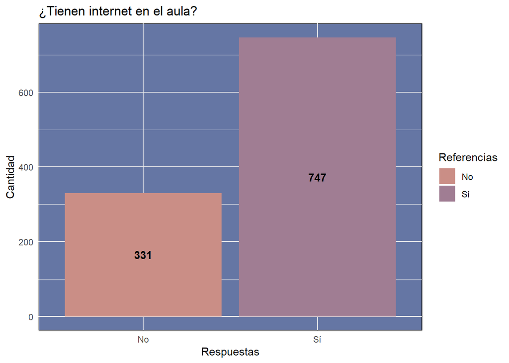

```r
Grafico_Escuelas <-ggplot(Total, aes(x=Respuestas, y=Total_Internet_Aula, fill=Respuestas))+
  geom_bar(stat = "identity")+
  scale_fill_manual(values=c("#CA8E86", "#A07D93", "#F0A36b" ))+
  theme_minimal() +
  theme(panel.background = element_rect(fill = '#6576A4')) +
  geom_text(aes(label=Total_Internet_Aula),  position = position_stack(vjust = 0.5), fontface = "bold") +
  ylab("Cantidad")+
  xlab("Respuestas")+
  labs(fill = "Referencias")+
  ggtitle("¿Tienen internet en el aula?")

Grafico_Escuelas
```